# Case studies in exploratory data analysis - Course Project 4

Course Notes from Coursera Exploratory Data Analysis

Mircea Dumitru

2023-01-23

Fine particulate matter (PM2.5) is an ambient air pollutant for which there is strong evidence that it is harmful to human health. In the United States, the Environmental Protection Agency (EPA) is tasked with setting national ambient air quality standards for fine PM and for tracking the emissions of this pollutant into the atmosphere. Approximatly every 3 years, the EPA releases its database on emissions of PM2.5. This database is known as the National Emissions Inventory (NEI). You can read more information about the NEI at the EPA National Emissions Inventory web site http://www.epa.gov/ttn/chief/eiinformation.html

For each year and for each type of PM source, the NEI records how many tons of PM2.5 were emitted from that source over the course of the entire year. The data that you will use for this assignment are for 1999, 2002, 2005, and 2008.

## Data

The data for this assignment are available from the course web site as a single zip file:

https://d396qusza40orc.cloudfront.net/exdata%2Fdata%2FNEI_data.zip

The zip file contains two files:

- fips: A five-digit number (represented as a string) indicating the U.S. county
- SCC: The name of the source as indicated by a digit string (see source code classification table)
- Pollutant: A string indicating the pollutant
- Emissions: Amount of PM2.5 emitted, in tons
- type: The type of source (point, non-point, on-road, or non-road)
- year: The year of emissions recorded

Source Classification Code Table (Source_Classification_Code.rds): This table provides a mapping from the SCC digit strings in the Emissions table to the actual name of the PM2.5 source. The sources are categorized in a few different ways from more general to more specific and you may choose to explore whatever categories you think are most useful. For example, source “10100101” is known as “Ext Comb /Electric Gen /Anthracite Coal /Pulverized Coal”.

## Assignment

The overall goal of this assignment is to explore the National Emissions Inventory database and see what it say about fine particulate matter pollution in the United states over the 10-year period 1999–2008. You may use any R package you want to support your analysis.

## Questions

You must address the following questions and tasks in your exploratory analysis. For each question/task you will need to make a single plot. Unless specified, you can use any plotting system in R to make your plot.

### Question 1

Have total emissions from PM2.5 decreased in the United States from 1999 to 2008? Using the base plotting system, make a plot showing the total PM2.5 emission from all sources for each of the years 1999, 2002, 2005, and 2008.

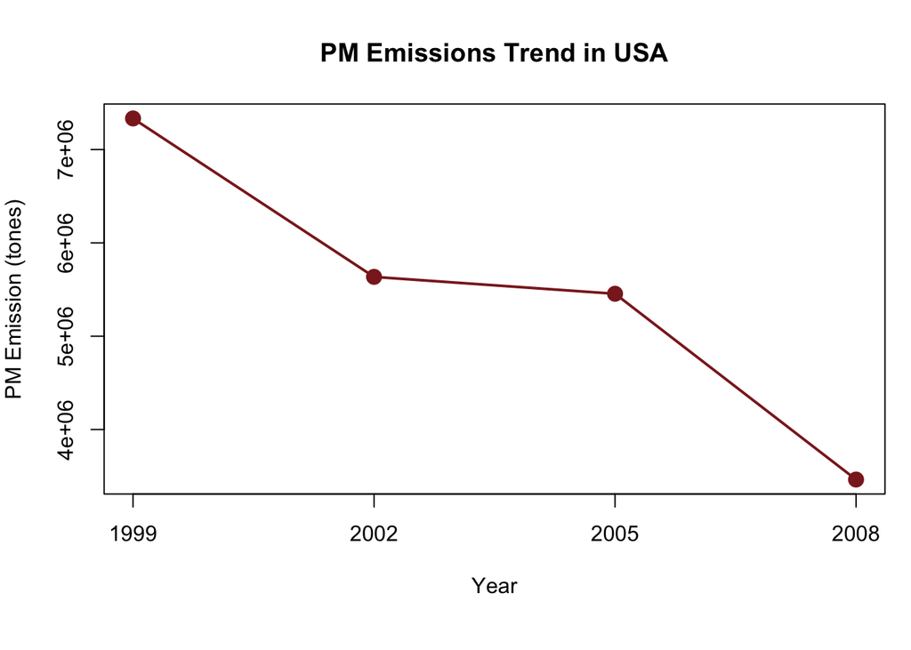

```r
NEI <- readRDS('./data/summarySCC_PM25.rds')

## Setting the dataframe so that
##   a) the numerical variables are in the numeric format.
##   b) the categorical variables are in the factor format

NEI <- transform(NEI, fips = as.numeric(fips), SCC = factor(SCC),
                 Emissions = as.numeric(Emissions), type = factor(type))

yearTotal <- with(NEI, tapply(Emissions, year, sum, na.rm = T))

par(mfrow = c(1,1), mar = c(6,4,4,1))
plot(as.numeric(names(yearTotal)), yearTotal,
     pch = 19, cex = 1.5, col = 'brown4',
     main = 'PM Emissions Trend in USA',
     xlab = 'Year', ylab = 'PM Emission (tones)', xaxt = "n")
lines(as.numeric(names(yearTotal)), yearTotal,
       lwd = 2, col = 'brown4')
axis(1, at = as.numeric(names(yearTotal)),
     labels = as.numeric(names(yearTotal)))
```

### Question 2

Have total emissions from PM2.5 decreased in the Baltimore City, Maryland (fips == “24510”) from 1999 to 2008? Use the base plotting system to make a plot answering this question.

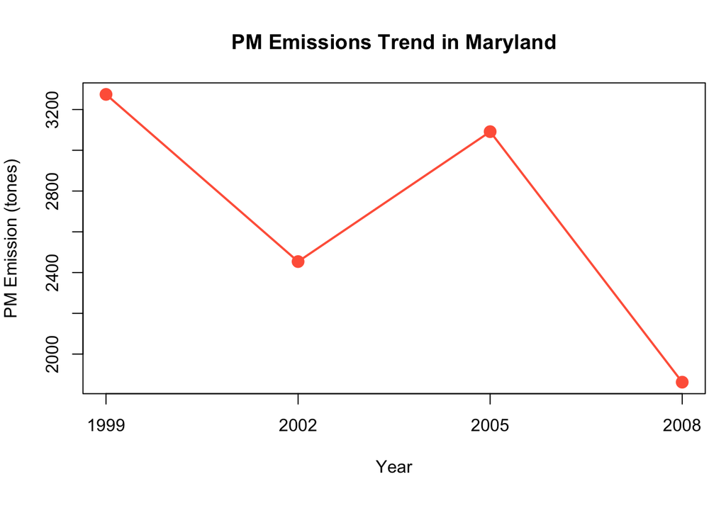

```r
NEIMaryland <- subset(NEI, fips == 24510)

yearTotalMaryland <- with(NEIMaryland,
                          tapply(Emissions, year, sum, na.rm = T))

par(mfrow = c(1,1), mar = c(6,4,4,1))
plot(as.numeric(names(yearTotalMaryland)), yearTotalMaryland,
     pch = 19, cex = 1.5, col = 'tomato1',
     main = 'PM Emissions Trend in Maryland',
     xlab = 'Year', ylab = 'PM Emission (tones)', xaxt = "n")
lines(as.numeric(names(yearTotalMaryland)), yearTotalMaryland,
      lwd = 2, col = 'tomato1')
axis(1, at = as.numeric(names(yearTotalMaryland)),
     labels = as.numeric(names(yearTotalMaryland)))
```

### Question 3

Of the four types of sources indicated by the type (point, nonpoint, onroad, nonroad) variable, which of these four sources have seen decreases in emissions from 1999–2008 for Baltimore City? Which have seen increases in emissions from 1999–2008? Use the ggplot2 plotting system to make a plot answer this question.

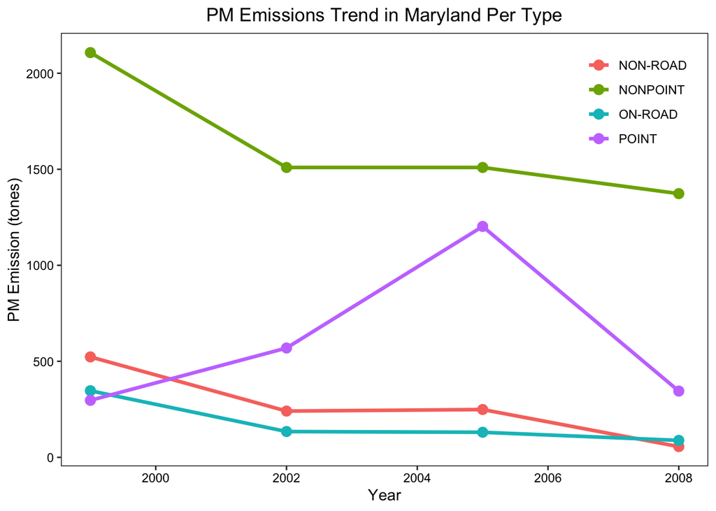

```r
library(ggplot2)
NEIMarylandAgg <- aggregate(Emissions ~ year + type, data = NEIMaryland, sum)

ggtheme <- theme(axis.text.x = element_text(colour='black'),
                 axis.text.y = element_text(colour='black'),
                 panel.background = element_blank(),
                 panel.grid.minor = element_blank(),
                 panel.grid.major = element_blank(),
                 panel.border = element_rect(colour='black', fill=NA),
                 strip.background = element_blank(),
                 legend.justification = c(0, 1),
                 legend.position = c(0.8, 0.99),
                 legend.background = element_rect(colour = NA),
                 legend.key = element_rect(colour = "white", fill = NA),
                 legend.title = element_blank(),
                 plot.title = element_text(hjust = 0.5))

g <- ggplot(NEIMarylandAgg,
            aes(x = year, y = Emissions, group = type)) +
            geom_line(linewidth = 1.2,
                      alpha = 1,
                      aes(col = type)) +
            geom_point(size = 3,
                       alpha = 1,
                       aes(col = type))

gl <- labs(title = "PM Emissions Trend in Maryland Per Type",
           x = 'Year',
           y = 'PM Emission (tones)')

g + gl + ggtheme
```

```r
## ggsave(file = "./Figures4/plot3.png", g + gl + ggtheme)
```

### Question 4

Across the United States, how have emissions from coal combustion-related sources changed from 1999–2008?

```r
SCC <- readRDS("./data/Source_Classification_Code.rds")

## Get the row indices that contain "[Cc]oal" by inspecting SCC.Level.Three and
## SCC.Level.Four information
coalL3 <- grep('[Cc]oal',SCC$SCC.Level.Three)
coalL4 <- grep('[Cc]oal',SCC$SCC.Level.Four)
## Get the union of the two for coal index positions
coalL <- sort(union(coalL3, coalL4))
## Get the row indexes that contain "[Cc]omb" by inspecting SCC.Level.One for
## for combustion index positions
combL <- grep('[Cc]omb',SCC$SCC.Level.One)
## Get the intersection of the two for coal-combustion correspondng indices
coalCombL <- intersect(coalL, combL)
## Get the corresponding SSC codes for coal-combustion related emissions
coalCombLSCC <- SCC$SCC[coalCombL]
## Get the dataframe subset corresponding to rows that contain the codes for
## coal-combustion related emissions
NEICC <- subset(NEI, SCC %in% coalCombLSCC)
head(NEICC)
```

```
##      fips        SCC Pollutant Emissions     type year
## 149  9001 2104001000  PM25-PRI     1.134 NONPOINT 1999
## 2277 9003 2104001000  PM25-PRI     3.842 NONPOINT 1999
## 4204 9005 2104001000  PM25-PRI     1.447 NONPOINT 1999
## 5967 9007 2104001000  PM25-PRI     1.574 NONPOINT 1999
## 7998 9009 2104001000  PM25-PRI     2.183 NONPOINT 1999
## 9979 9011   10100217  PM25-PRI   479.907    POINT 1999
```

```r
yearTotalCC <- with(NEICC, tapply(Emissions, year, sum, na.rm = T))
print(yearTotalCC)
```

```
##     1999     2002     2005     2008
## 575206.5 547380.1 553549.4 343979.3
```

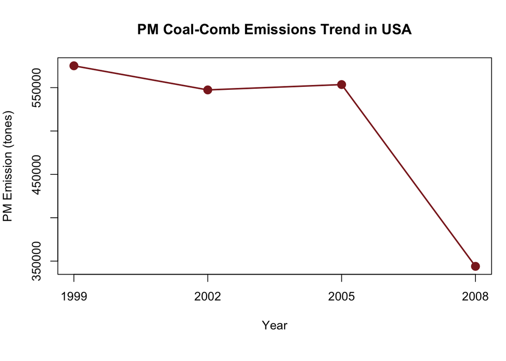

```r
par(mfrow = c(1,1), mar = c(6,4,4,1))
plot(as.numeric(names(yearTotalCC)), yearTotalCC,
     pch = 19, cex = 1.5, col = 'brown4',
     main = 'PM Coal-Comb Emissions Trend in USA',
     xlab = 'Year', ylab = 'PM Emission (tones)', xaxt = "n")
lines(as.numeric(names(yearTotalCC)), yearTotalCC,
      lwd = 2, col = 'brown4')
axis(1, at = as.numeric(names(yearTotalCC)),
     labels = as.numeric(names(yearTotalCC)))
```

### Question 5

How have emissions from motor vehicle sources changed from 1999–2008 in Baltimore City?

```r
vehicle <- grep('[Vv]ehicle',SCC$SCC.Level.Two)
vehicleSCC <- SCC$SCC[vehicle]

NEIMarylandVehicle <- subset(NEI, fips == 24510 & SCC %in% vehicleSCC)
head(NEIMarylandVehicle)
```

```
##         fips        SCC Pollutant Emissions    type year
## 114470 24510 220100123B  PM25-PRI      7.38 ON-ROAD 1999
## 114472 24510 220100123T  PM25-PRI      2.78 ON-ROAD 1999
## 114477 24510 220100123X  PM25-PRI     11.76 ON-ROAD 1999
## 114479 24510 220100125B  PM25-PRI      3.50 ON-ROAD 1999
## 114481 24510 220100125T  PM25-PRI      1.32 ON-ROAD 1999
## 114486 24510 220100125X  PM25-PRI      5.58 ON-ROAD 1999
```

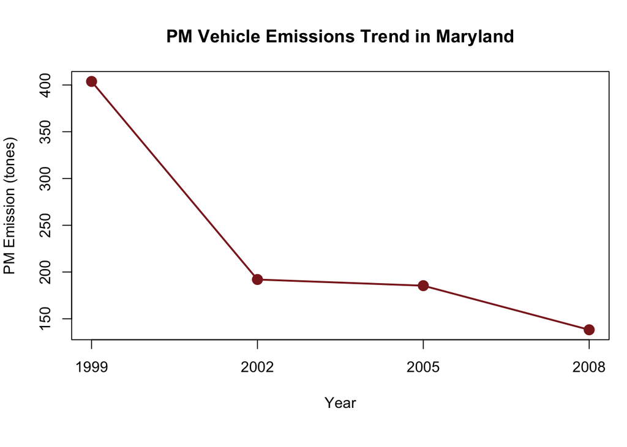

```r
yearTotalMarylandVehicle <- with(NEIMarylandVehicle,
                               tapply(Emissions, year, sum, na.rm = T))

par(mfrow = c(1,1), mar = c(6,4,4,1))
plot(as.numeric(names(yearTotalMarylandVehicle)), yearTotalMarylandVehicle,
     pch = 19, cex = 1.5, col = 'brown4',
     main = 'PM Vehicle Emissions Trend in Maryland',
     xlab = 'Year', ylab = 'PM Emission (tones)', xaxt = "n")
lines(as.numeric(names(yearTotalMarylandVehicle)), yearTotalMarylandVehicle,
      lwd = 2, col = 'brown4')
axis(1, at = as.numeric(names(yearTotalMarylandVehicle)),
     labels = as.numeric(names(yearTotalMarylandVehicle)))
```

### Question 6

Compare emissions from motor vehicle sources in Baltimore City with emissions from motor vehicle sources in Los Angeles County, California (fips == “06037”). Which city has seen greater changes over time in motor vehicle emissions?

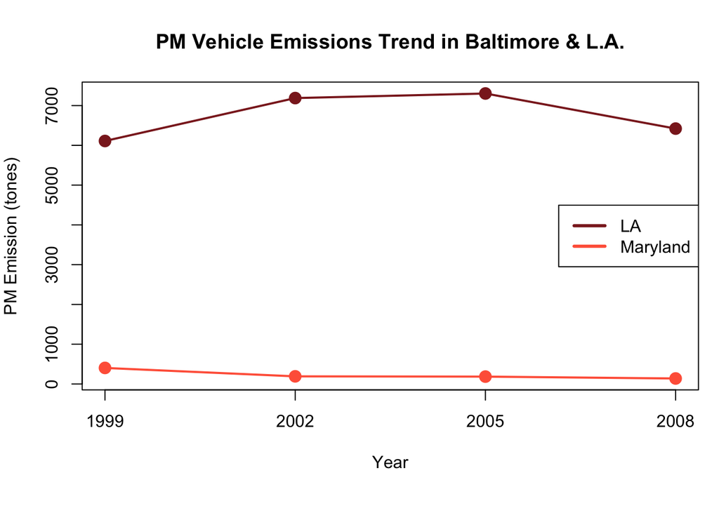

```r
vehicle <- grep('[Vv]ehicle',SCC$SCC.Level.Two)
vehicleSCC <- SCC$SCC[vehicle]

NEIMarylandVehicle <- subset(NEI, fips == 24510 & SCC %in% vehicleSCC)
NEICaliforniaVehicle <- subset(NEI, fips == 06037 & SCC %in% vehicleSCC)

yearTotalMarylandVehicle <- with(NEIMarylandVehicle,
                                 tapply(Emissions, year, sum, na.rm = T))
yearTotalCaliforniaVehicle <- with(NEICaliforniaVehicle,
                                 tapply(Emissions, year, sum, na.rm = T))

rng <- range(yearTotalCaliforniaVehicle, yearTotalMarylandVehicle)


par(mfrow = c(1,1), mar = c(6,4,4,1))

plot(as.numeric(names(yearTotalCaliforniaVehicle)), yearTotalCaliforniaVehicle,
     pch = 19, cex = 1.5, col = 'brown4',
     main = 'PM Vehicle Emissions Trend in Baltimore & L.A.',
     xlab = 'Year', ylab = 'PM Emission (tones)',
     ylim = rng, xaxt = "n")
lines(as.numeric(names(yearTotalCaliforniaVehicle)), yearTotalCaliforniaVehicle,
      lwd = 2, col = 'brown4')

points(as.numeric(names(yearTotalMarylandVehicle)), yearTotalMarylandVehicle,
     pch = 19, cex = 1.5, col = 'tomato1')
lines(as.numeric(names(yearTotalMarylandVehicle)), yearTotalMarylandVehicle,
      lwd = 2, col = 'tomato1')

axis(1, at = as.numeric(names(yearTotalMarylandVehicle)),
     labels = as.numeric(names(yearTotalMarylandVehicle)))

legend("right", legend = c("LA", "Maryland"),
       lwd = 3, col = c("brown4", "tomato1"))
```